# 项目：TMDB电影数据探索与分析

## 目录

- 简介
- 数据整理
- 探索性数据分析
- 结论

## 简介

> 本报告探索的数据集来源为“电影数据库”（TMDb，The Movie Database），其中包含 1 万条电影信息，包括用户评分和票房等等。本报告对TMDB中的电影类别和票房进行了探索分析，并得出了一些结论。

```python
# 用这个框对你计划使用的所有数据包进行设置
#   导入语句。
import pandas as pd
import numpy as np
import matplotlib.pyplot as plt
%matplotlib inline
#更改字体
plt.rcParams['font.sans-serif'] = ['SimHei']
# 务必包含一个‘magic word’（带有“%”的***），以便将你的视图
#   与 notebook 保持一致。关于更多信息，请访问该网页：
#   http://ipython.readthedocs.io/en/stable/interactive/magics.html
```

## 数据整理

> 载入数据，并对数据进行理解和评估，检查简洁度，然后整理和清理数据集，以便进行分析。

### 常规属性

```python
# 加载数据并打印几行。进行这几项操作，来检查数据
# 类型，以及是否有缺失数据或错误数据的情况。
tmdb = pd.read_csv('tmdb-movies.csv')
```

```python
#查看数据基本情况
#查看第一行
tmdb.head(1)
```

|  | id | imdb_id | popularity | budget | revenue | original_title | cast | homepage | director | tagline | ... | overview | runtime | genres | production_companies | release_date | vote_count | vote_average | release_year | budget_adj | revenue_adj |
| --- | --- | --- | --- | --- | --- | --- | --- | --- | --- | --- | --- | --- | --- | --- | --- | --- | --- | --- | --- | --- | --- |
| 0 | 135397 | tt0369610 | 32.985763 | 150000000 | 1513528810 | Jurassic World | Chris Pratt\|Bryce Dallas Howard\|Irrfan Khan\|Vi... | http://www.jurassicworld.com/ | Colin Trevorrow | The park is open. | ... | Twenty-two years after the events of Jurassic ... | 124 | Action\|Adventure\|Science Fiction\|Thriller | Universal Studios\|Amblin Entertainment\|Legenda... | 6/9/15 | 5562 | 6.5 | 2015 | 1.379999e+08 | 1.392446e+09 |

1 rows × 21 columns

从原始数据集第一行可以看出，原始数据集一共有21列，查看一下数据集基本情况。

```python
#查看数据集基本信息
tmdb.info()
```

```
<class 'pandas.core.frame.DataFrame'>
RangeIndex: 10866 entries, 0 to 10865
Data columns (total 21 columns):
id                      10866 non-null int64
imdb_id                 10856 non-null object
popularity              10866 non-null float64
budget                  10866 non-null int64
revenue                 10866 non-null int64
original_title          10866 non-null object
cast                    10790 non-null object
homepage                2936 non-null object
director                10822 non-null object
tagline                 8042 non-null object
keywords                9373 non-null object
overview                10862 non-null object
runtime                 10866 non-null int64
genres                  10843 non-null object
production_companies    9836 non-null object
release_date            10866 non-null object
vote_count              10866 non-null int64
vote_average            10866 non-null float64
release_year            10866 non-null int64
budget_adj              10866 non-null float64
revenue_adj             10866 non-null float64
dtypes: float64(4), int64(6), object(11)
memory usage: 1.7+ MB
```

根据数据集基本信息可以看出，此原始数据集一共有21列，10866条数据，其中imdb_id、cast、homepage、director、tagline、keywords、overview、genres、production_companies列存在数据缺失，参考项目提供的探索数据集文档，对数据进行理解并提出需要探索的问题。

### **数据理解**

数据集各列代表含义为：

- id 编号
- imdb_id 电影编号
- popularity 受欢迎程度
- budget 预算
- revenue 收入
- original_title 电影标题
- cast 演职人员，包含由竖线字符"|"分隔的多个数值
- homepage 电影主页
- director 导演
- tagline 电影标语
- keywords 电影关键词
- overview 电影内容概要
- runtime 电影时长
- genres 电影类别，包含由竖线字符(|)分隔的多个数值
- production_companies 电影制造公司，包含由竖线字符(|)分隔的多个数值
- release_date 上映时间
- vote_count 参与评分的人数
- vote_average 评分均值
- release_year 上映年份
- budget_adj 考虑了通货膨胀之后的相关电影的预算
- revenue_adj 考虑了通货膨胀之后的相关电影的收入

### **提出问题**

根据数据集各列含义，提出本报告需要进行探索的问题

1. 对电影类别进行分析，电影类别有哪些？那种类别的电影最多？哪种类别的电影更受欢迎？
2. 票房高的电影有哪些特点？

### 数据清理

1.根据原始数据集情况以及需要分析的问题，删除不需要的数据列。  
对于预算和收入，选择考虑通货膨胀之后的数据，即budget_adj与revenue_adj。

```python
#删除不需要的列，并查看处理后的数据基本情况
df1 = tmdb.drop(['imdb_id', 'budget', 'revenue', 'original_title', 'cast', 'homepage', 'director', 'tagline', 'keywords', 'overview', 'production_companies', 'release_date', 'vote_count'], axis = 1)
df1.info()
```

```
<class 'pandas.core.frame.DataFrame'>
RangeIndex: 10866 entries, 0 to 10865
Data columns (total 8 columns):
id              10866 non-null int64
popularity      10866 non-null float64
runtime         10866 non-null int64
genres          10843 non-null object
vote_average    10866 non-null float64
release_year    10866 non-null int64
budget_adj      10866 non-null float64
revenue_adj     10866 non-null float64
dtypes: float64(4), int64(3), object(1)
memory usage: 679.2+ KB
```

2.处理数据冗余

```python
#查看冗余数据个数
sum(df1.duplicated())
```

```
1
```

```python
#删除冗余数据个数并验证删除冗余结果
df1.drop_duplicates(inplace = True)
sum(df1.duplicated())
```

```
0
```

3.空值处理  
需要分析的数据中，genres列存在空值23个，相对于整个数据集总数来说，空值较少，删除空值对整个数据集影响不大。

```python
#删除空值
df1.dropna(axis = 0, inplace = True)
#查看删除空值后的结果
df1.info()
```

```
<class 'pandas.core.frame.DataFrame'>
Int64Index: 10842 entries, 0 to 10865
Data columns (total 8 columns):
id              10842 non-null int64
popularity      10842 non-null float64
runtime         10842 non-null int64
genres          10842 non-null object
vote_average    10842 non-null float64
release_year    10842 non-null int64
budget_adj      10842 non-null float64
revenue_adj     10842 non-null float64
dtypes: float64(4), int64(3), object(1)
memory usage: 762.3+ KB
```

数据集中已经无空值，可以对此数据集进行数据探索分析

## 探索性数据分析

### 研究问题 1.对电影类别进行分析，电影类别有哪些？那种类别的电影最多？哪种类别的电影更受欢迎？

要对数据集的电影类别进行分析，需要获取电影类别，首先查看数据集中genres列的1个值

```python
#创建df1的副本df2，对df2进行操作
df2 = df1.copy()
df2['genres'][1]
```

```
'Action|Adventure|Science Fiction|Thriller'
```

genres列包含由竖线字符“|”分隔的多个数值  
为了获取数据集中的所有类别，可以使用set() 函数创建一个无序不重复元素集，这个集合可进行关系测试，删除重复数据，还可以计算交集、差集、并集等

```python
#创建一个set()，使用for循环，使用union(联合)取并集set(a).union(b)
all_genres = set()
for genre in df2['genres'].str.split('|'):
    all_genres = set().union(genre, all_genres)
#将all_genres转换为列表
all_genres = list(all_genres)
all_genres
```

```
['Thriller',
 'History',
 'Mystery',
 'Fantasy',
 'Animation',
 'Science Fiction',
 'Drama',
 'TV Movie',
 'Romance',
 'War',
 'Music',
 'Comedy',
 'Adventure',
 'Horror',
 'Crime',
 'Western',
 'Action',
 'Family',
 'Documentary',
 'Foreign']
```

输出的 all_genres 表示了此数据集中的所有电影类别，将这些电影类别当做列添加至原数据集中，获取每一部电影的类别

```python
#使用for循环，获取每个电影的类型，该电影包含哪个类型，就返回1，否则返回0
for genre in all_genres:
    df2[genre] = df2['genres'].str.contains(genre).apply(lambda x: 1 if x else 0)
#查看结果
df2.head(1)
```

|  | id | popularity | runtime | genres | vote_average | release_year | budget_adj | revenue_adj | Thriller | History | ... | Music | Comedy | Adventure | Horror | Crime | Western | Action | Family | Documentary | Foreign |
| --- | --- | --- | --- | --- | --- | --- | --- | --- | --- | --- | --- | --- | --- | --- | --- | --- | --- | --- | --- | --- | --- |
| 0 | 135397 | 32.985763 | 124 | Action\|Adventure\|Science Fiction\|Thriller | 6.5 | 2015 | 1.379999e+08 | 1.392446e+09 | 1 | 0 | ... | 0 | 0 | 1 | 0 | 0 | 0 | 1 | 0 | 0 | 0 |

1 rows × 28 columns

创建新的DataFrame，删除原genres列

```python
df_genres = df2.drop('genres', axis =1)
df_genres.head(1)
```

|  | id | popularity | runtime | vote_average | release_year | budget_adj | revenue_adj | Thriller | History | Mystery | ... | Music | Comedy | Adventure | Horror | Crime | Western | Action | Family | Documentary | Foreign |
| --- | --- | --- | --- | --- | --- | --- | --- | --- | --- | --- | --- | --- | --- | --- | --- | --- | --- | --- | --- | --- | --- |
| 0 | 135397 | 32.985763 | 124 | 6.5 | 2015 | 1.379999e+08 | 1.392446e+09 | 1 | 0 | 0 | ... | 0 | 0 | 1 | 0 | 0 | 0 | 1 | 0 | 0 | 0 |

1 rows × 27 columns

计算整个数据集中的各种电影类别的总数，并降序排列，绘制各种电影类别数量的横向条形图

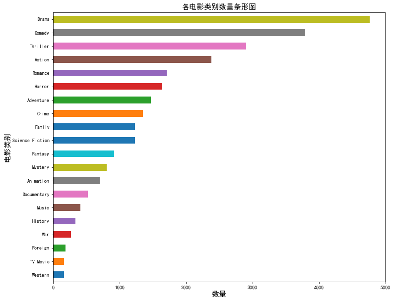

```python
#使用sort_values()方法对汇总后的数据进行降序排列
df_genres_sum = df_genres.loc[:, all_genres].sum().sort_values(ascending=True)
df_genres_sum.plot.barh(label = 'all_genres', figsize = (12,10))
plt.title('各电影类别数量条形图', fontsize =15)
plt.ylabel('电影类别', fontsize = 15)
plt.xlabel('数量', fontsize = 15)
plt.show()
```

绘制饼图查看各类别的占比情况

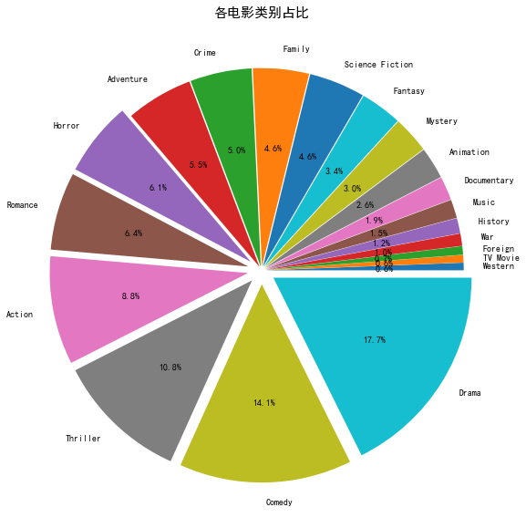

```python
#计算各种类型所占比例
proportion = df_genres_sum/ df_genres_sum.sum()
#所占比例大于0.06时，突出显示
explode = (proportion > 0.06)/ 20 + 0.02
#设置饼图参数
df_genres_sum.plot.pie(autopct = '%1.1f%%', figsize = (10,10), label = '', explode = explode)
plt.title('各电影类别占比', fontsize = 15)
plt.show()
```

继续分析各个电影类别的受欢迎程度，首先计算每种电影类别的受欢迎程度(popularity)的均值

```python
#创建新的DataFrame，以各个电影类别作为索引，列数据为该类型popularity均值
df_genres_pop = pd.DataFrame(index = all_genres)
#求每种类别的平均受欢迎程度
#建立一个列表list，储存该类别对应两种情况0,1的popularity的均值
#使用for循环遍历所有类别，使用list.append()方法在列表末尾添加对应值0,1的popularity均值
list = []
for genre in all_genres:
    list.append(df_genres.groupby(genre)['popularity'].mean())
#创建一个列表，使用range(len(list1))遍历list，取list中每个类别值为1的popularity均值
list2=[]
for i in range(len(all_genres)):
    list2.append(list[i][1])
df_genres_pop['popularity_mean'] = list2
df_genres_pop.head(1)
```

|  | popularity_mean |
| --- | --- |
| Thriller | 0.741563 |

对各种类别的popularity_mean降序排列后，绘制各个电影类别的受欢迎程度横向条形图

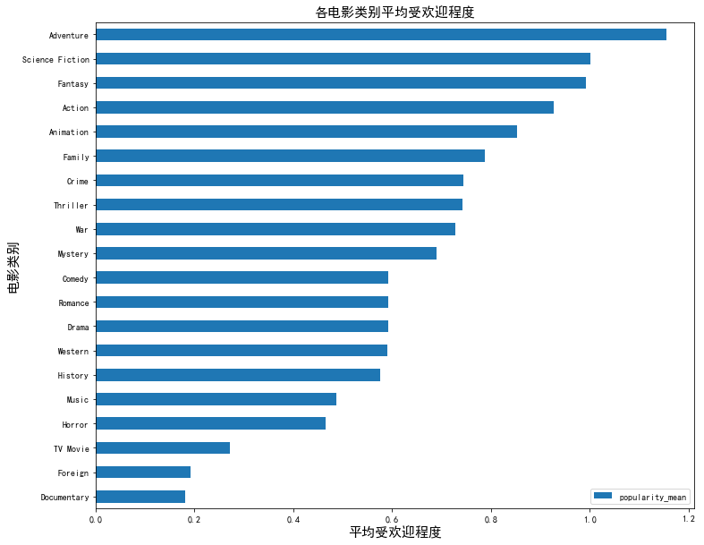

```python
df_genres_pop.sort_values(by='popularity_mean', ascending = True).plot.barh(label = 'all_genres', figsize = (12,10))
plt.title('各电影类别平均受欢迎程度', fontsize = 15)
plt.ylabel('电影类别', fontsize = 15)
plt.xlabel('平均受欢迎程度', fontsize = 15)
plt.show()
```

从条形图可以看出，Adventure类的电影最受欢迎，其次是Science Fiction。

### 研究问题 2.票房高的电影有哪些特点？

选取收入大于平均收入的数据作为高票房数据，对这些数据进行分析

```python
df_highreveue = df1[df1['revenue_adj'] > (df1['revenue_adj'].mean())]
df_highreveue.head(1)
```

|  | id | popularity | runtime | genres | vote_average | release_year | budget_adj | revenue_adj |
| --- | --- | --- | --- | --- | --- | --- | --- | --- |
| 0 | 135397 | 32.985763 | 124 | Action\|Adventure\|Science Fiction\|Thriller | 6.5 | 2015 | 1.379999e+08 | 1.392446e+09 |

查看原数据集中的统计描述

```python
df1.describe()
```

|  | id | popularity | runtime | vote_average | release_year | budget_adj | revenue_adj |
| --- | --- | --- | --- | --- | --- | --- | --- |
| count | 10842.000000 | 10842.000000 | 10842.000000 | 10842.000000 | 10842.000000 | 1.084200e+04 | 1.084200e+04 |
| mean | 65870.675521 | 0.647461 | 102.138443 | 5.974064 | 2001.314794 | 1.758712e+07 | 5.147797e+07 |
| std | 91981.355752 | 1.001032 | 31.294612 | 0.934257 | 12.813617 | 3.433437e+07 | 1.447723e+08 |
| min | 5.000000 | 0.000065 | 0.000000 | 1.500000 | 1960.000000 | 0.000000e+00 | 0.000000e+00 |
| 25% | 10589.250000 | 0.208210 | 90.000000 | 5.400000 | 1995.000000 | 0.000000e+00 | 0.000000e+00 |
| 50% | 20557.000000 | 0.384532 | 99.000000 | 6.000000 | 2006.000000 | 0.000000e+00 | 0.000000e+00 |
| 75% | 75186.000000 | 0.715393 | 111.000000 | 6.600000 | 2011.000000 | 2.092507e+07 | 3.387838e+07 |
| max | 417859.000000 | 32.985763 | 900.000000 | 9.200000 | 2015.000000 | 4.250000e+08 | 2.827124e+09 |

查看高票房数据集中的统计描述

```python
df_highreveue.describe()
```

|  | id | popularity | runtime | vote_average | release_year | budget_adj | revenue_adj |
| --- | --- | --- | --- | --- | --- | --- | --- |
| count | 2261.000000 | 2261.000000 | 2261.00000 | 2261.000000 | 2261.000000 | 2.261000e+03 | 2.261000e+03 |
| mean | 31956.323751 | 1.557742 | 113.05617 | 6.306369 | 1999.214065 | 5.830409e+07 | 2.282261e+08 |
| std | 60133.554335 | 1.767902 | 24.06729 | 0.735536 | 12.460245 | 5.049916e+07 | 2.461158e+08 |
| min | 11.000000 | 0.010335 | 44.00000 | 3.400000 | 1960.000000 | 0.000000e+00 | 5.152769e+07 |
| 25% | 2157.000000 | 0.665367 | 98.00000 | 5.800000 | 1992.000000 | 2.203826e+07 | 8.361457e+07 |
| 50% | 9919.000000 | 1.102836 | 110.00000 | 6.300000 | 2002.000000 | 4.466253e+07 | 1.421194e+08 |
| 75% | 21845.000000 | 1.832434 | 124.00000 | 6.800000 | 2009.000000 | 8.102293e+07 | 2.682159e+08 |
| max | 417859.000000 | 32.985763 | 705.00000 | 8.300000 | 2015.000000 | 3.683713e+08 | 2.827124e+09 |

对比两数据集，可以看出高票房数据集中的popularity，vote_average，budget_adj，revenue_adj的平均值都比原数据集对应的均值要高

绘制高票房数据集的popularity，runtime，vote_average，budget_adj，revenue_adj直方图查看其分布

```
array([[<matplotlib.axes._subplots.AxesSubplot object at 0x000001C39DAF1898>,
      dtype=object)
```

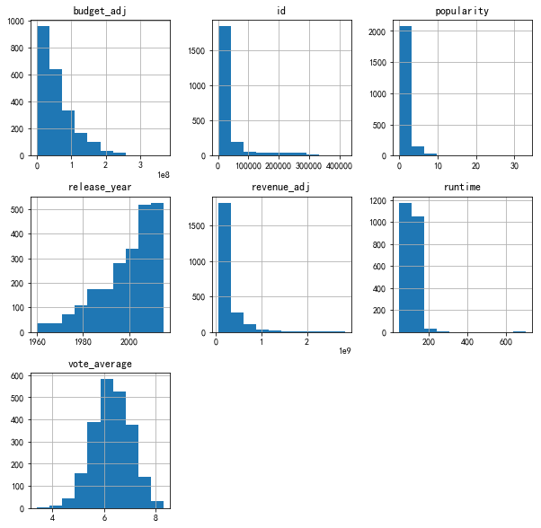

```python
df_highreveue.hist(figsize = (10,10))
```

通过直方图可以看出，popularity，runtime，budget_adj，revenue_adj都呈右偏分布，vote_average大致呈正态分布

绘制popularity，runtime，vote_average，budget_adj与revenue_adj的散点图，查看他们之间的关系

1. 绘制电影受欢迎程度与票房的散点图

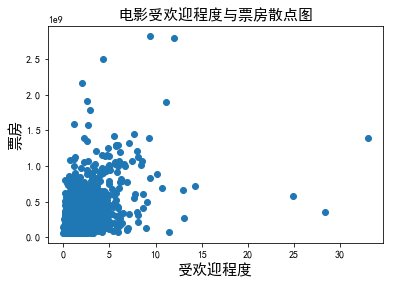

```python
plt.scatter(x = df_highreveue.popularity, y = df_highreveue.revenue_adj)
plt.ylabel('票房', fontsize = 15)
plt.xlabel('受欢迎程度', fontsize = 15)
plt.title('电影受欢迎程度与票房散点图', fontsize = 15)
plt.show()
```

1. 绘制电影时长与票房的散点图

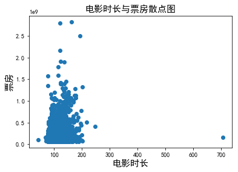

```python
plt.scatter(x = df_highreveue.runtime, y = df_highreveue.revenue_adj)
plt.ylabel('票房', fontsize = 15)
plt.xlabel('电影时长', fontsize = 15)
plt.title('电影时长与票房散点图', fontsize = 15)
plt.show()
```

1. 绘制电影评分与票房的散点图

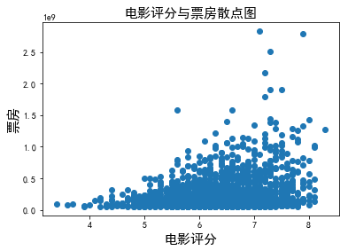

```python
plt.scatter(x = df_highreveue.vote_average, y = df_highreveue.revenue_adj)
plt.ylabel('票房', fontsize = 15)
plt.xlabel('电影评分', fontsize = 15)
plt.title('电影评分与票房散点图', fontsize = 15)
plt.show()
```

1. 绘制电影预算与票房的散点图

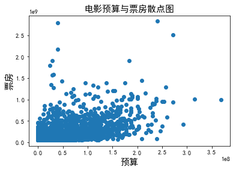

```python
plt.scatter(x = df_highreveue.budget_adj, y = df_highreveue.revenue_adj)
plt.ylabel('票房', fontsize = 15)
plt.xlabel('预算', fontsize = 15)
plt.title('电影预算与票房散点图', fontsize = 15)
plt.show()
```

## 结论

### 对于问题1

- 输出的 all_genres 表示了此数据集中的所有电影类别，一共20种，分别是:  
  Western,Family,Crime,Music,Adventure,Romance,Mystery,Foreign,Thriller,Drama,  
  War,Comedy,Horror,Animation,Science,Fiction,Documentary,History,Fantasy,Action,TV,Movie
- 根据各电影类别条形图的显示结果，Drama类的电影最多。
- 通过各电影类别占比饼图可以看出，数量最多的前三种电影类别为Drama，占比17.7%，Comedy，占比14.1%，Thriller，占比10.8% 。
- 从各电影类别平均受欢迎程度条形图可以看出，Adventure类的电影最受欢迎，其次是Science Fiction。

### 总结

```python
from subprocess import call
call(['python', '-m', 'nbconvert', 'Investigate_a_Dataset.ipynb'])
```

```
4294967295
```